# Proyecto_completo

Larissa Cordero

2023-10-24

# Resultados muestras vid Perú

## *Análisis:* Actividad Enzimática, Conteo total de hongos y Bacterias.

```r
Resultados <- read.csv("~/capR/curso/curso_Innovak/Proyecto/Datos/Muestras_peru.csv")

Estanque_de_plantas <- read.csv("~/capR/curso/curso_Innovak/Material_clase/Estanque_plantas.csv")


library(dplyr)
library(tidyverse)
library(car)
library(agricolae)
library(latexpdf)
library(tinytex)
```

*Verificación de datos*

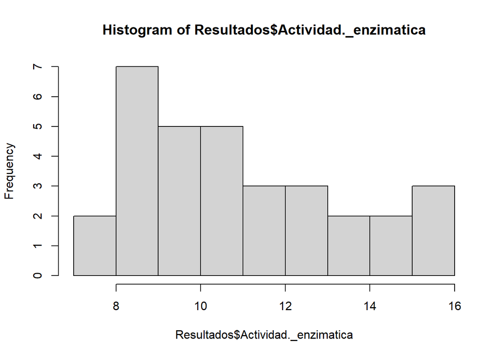

```r
# Actividad_enzimatica

hist(Resultados$Actividad._enzimatica)
```

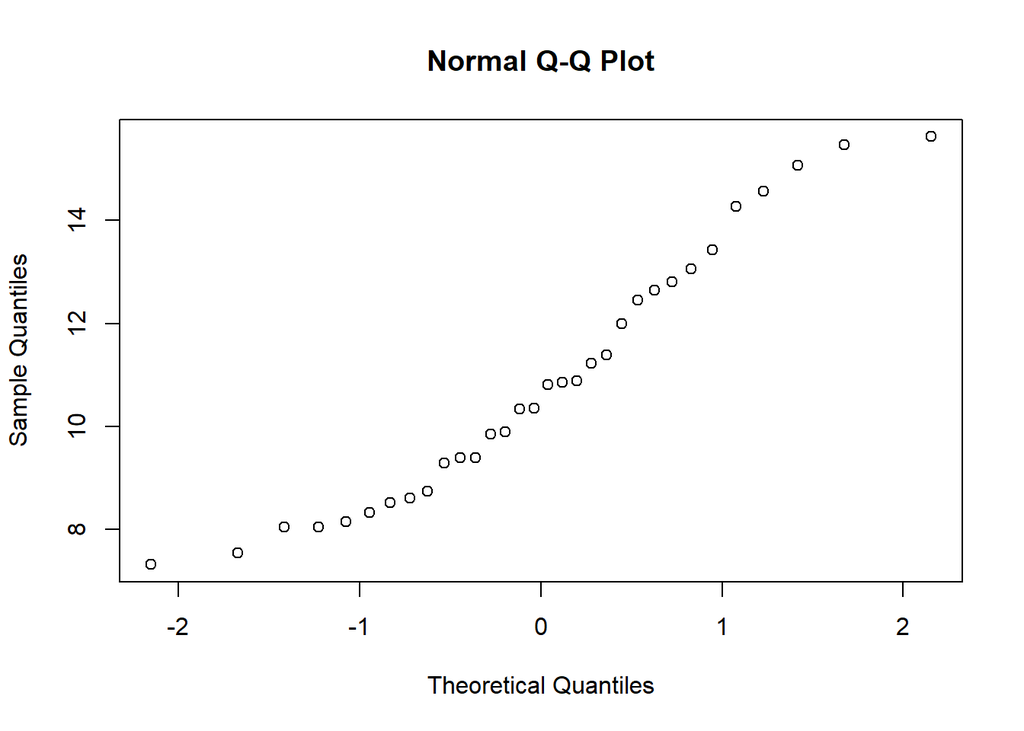

```r
qqnorm(Resultados$Actividad._enzimatica)
```

```r
shapiro.test(Resultados$Actividad._enzimatica)
```

```
##
##  Shapiro-Wilk normality test
##
## data:  Resultados$Actividad._enzimatica
## W = 0.94319, p-value = 0.09226
```

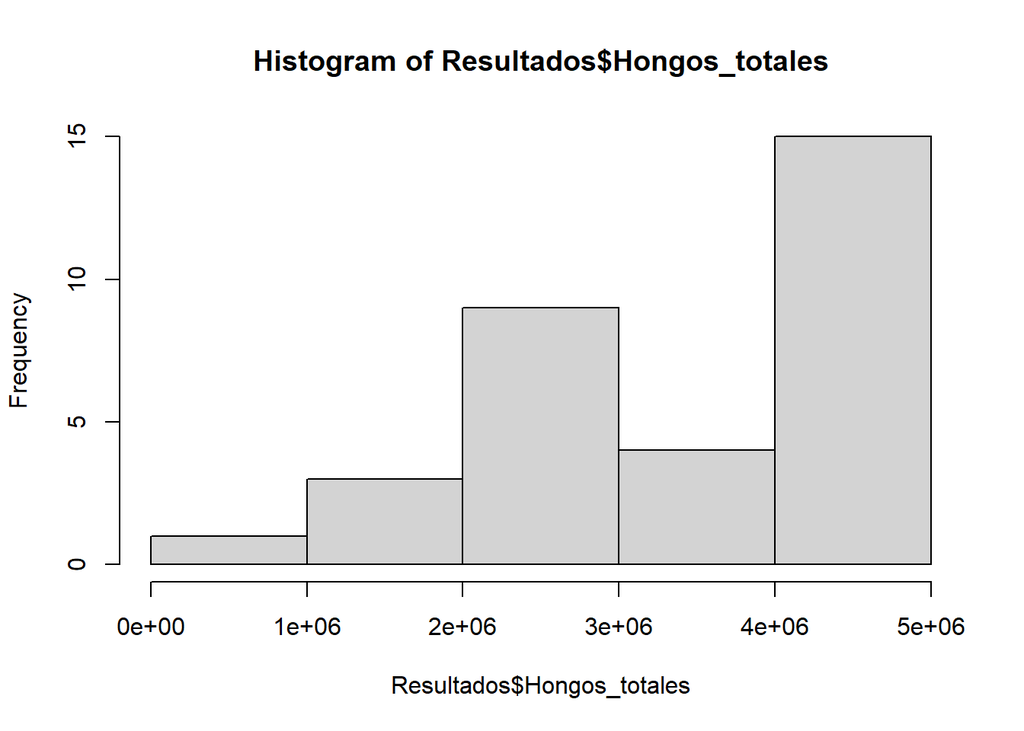

```r
# Hongos_totales

hist(Resultados$Hongos_totales)
```

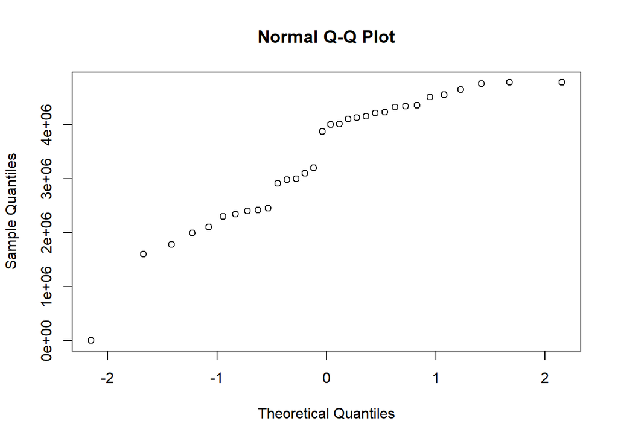

```r
qqnorm(Resultados$Hongos_totales)
```

```r
shapiro.test(Resultados$Hongos_totales)
```

```
##
##  Shapiro-Wilk normality test
##
## data:  Resultados$Hongos_totales
## W = 0.90174, p-value = 0.006859
```

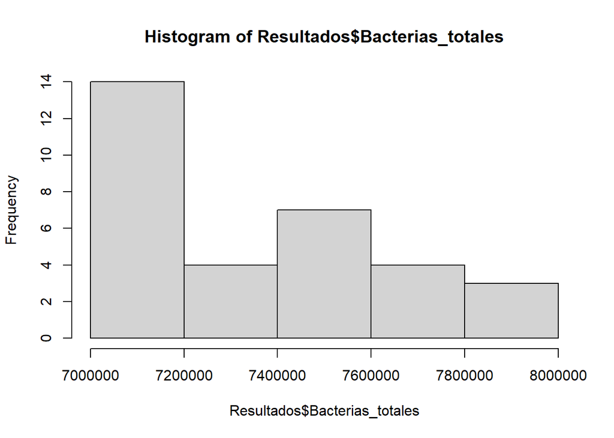

```r
# Bacterias_totales

hist(Resultados$Bacterias_totales)
```

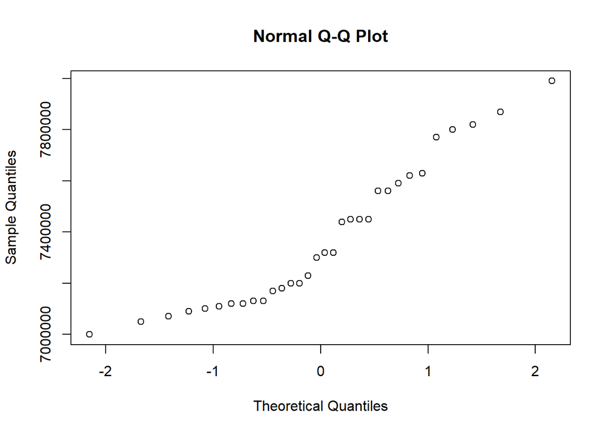

```r
qqnorm(Resultados$Bacterias_totales)
```

```r
shapiro.test(Resultados$Bacterias_totales) # Normalizar datos
```

```
##
##  Shapiro-Wilk normality test
##
## data:  Resultados$Bacterias_totales
## W = 0.91461, p-value = 0.01489
```

```r
shapiro.test(log(Resultados$Bacterias_totales))
```

```
##
##  Shapiro-Wilk normality test
##
## data:  log(Resultados$Bacterias_totales)
## W = 0.91846, p-value = 0.01888
```

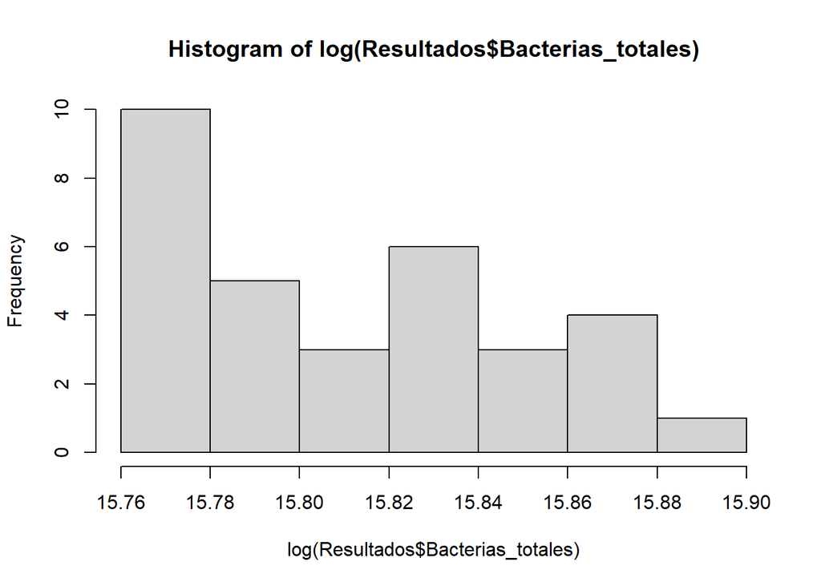

```r
hist(log(Resultados$Bacterias_totales))
```

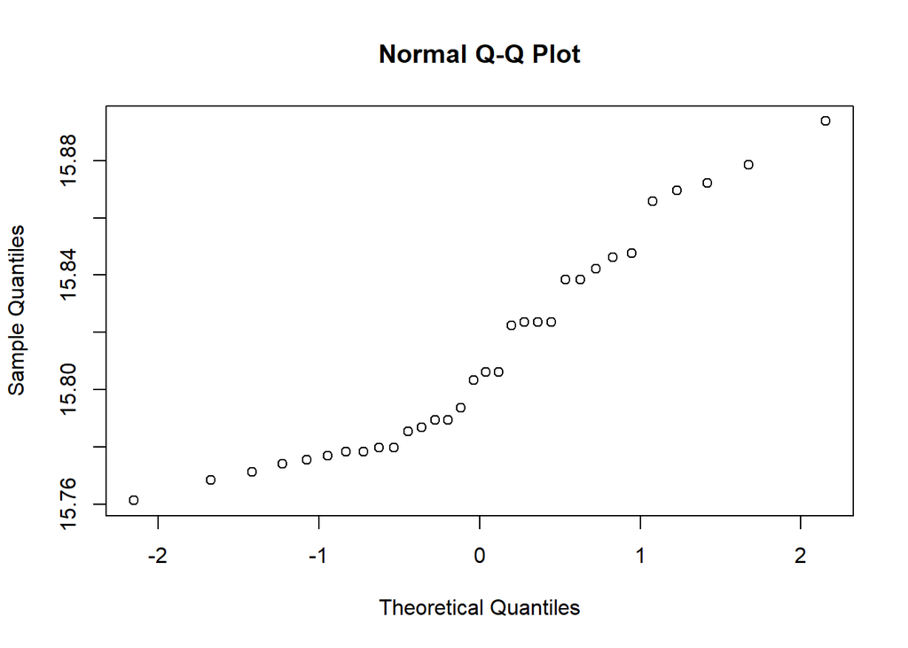

```r
qqnorm(log(Resultados$Bacterias_totales))
```

```r
# Verificar el balance de los datos

Resultados %>%
  group_by(Variedad) %>%
  summarise (n())
```

| Variedad | n() |
| --- | --- |
| Cotton candy | 16 |
| Sweet globe | 16 |

```r
# Homogenidad de varianza


leveneTest(log(Bacterias_totales) ~ Variedad*Tipo_muestra, data = Resultados) # no hay homogeneidad
```

|  | Df | F value | Pr(>F) |
| --- | --- | --- | --- |
| group | 3 | 4.504471 | 0.01062165 |
|  | 28 | NA | NA |

```r
leveneTest(Actividad._enzimatica ~ Variedad*Tipo_muestra, data = Resultados) # si hay homogeneidad
```

|  | Df | F value | Pr(>F) |
| --- | --- | --- | --- |
| group | 3 | 0.7425682 | 0.5357013 |
|  | 28 | NA | NA |

### Los resultados de verificación son los siguientes:

#### **Actividad_enzimatica**:

*Shapiro*= 0.09226 Conforme a los resultados de shapiro, es >0.05, por lo cual ya estan normalizados los datos y también con las graficas se puede observar que si.

#### **Balance de datos**:

Es importante verificar que se cuente con el mismo numero de datos, en este analisis se cuenta con 16 datos para la variedad *cotton candy* y 16 para *sweet globe*

#### **Homogeneidad de varianza**:

Se realizó la prueba de Levene arrojando los siguientes resultados

1.*Bacterias_totales*: p= 0.01062 2.*Actividad_ezimatica*:p = 0.5357

##### Con los resultados anteriores se concluye que si hay homogeneidad con los datos de actividad enzimatica y que con la interacción de los datos con Bacterias_totales no hay homogeneidad.

### **ANOVA**

```r
# Anova dos vías

Anova_enz <- aov(Actividad._enzimatica ~ Variedad*Tipo_muestra, data = Resultados)

Anova(Anova_enz)
```

|  | Sum Sq | Df | F value | Pr(>F) |
| --- | --- | --- | --- | --- |
| Variedad | 4.247127 | 1 | 2.242098 | 1.454879e-01 |
| Tipo_muestra | 126.769254 | 1 | 66.922663 | 6.630464e-09 |
| Variedad:Tipo_muestra | 2.846964 | 1 | 1.502939 | 2.304310e-01 |
| Residuals | 53.039418 | 28 | NA | NA |

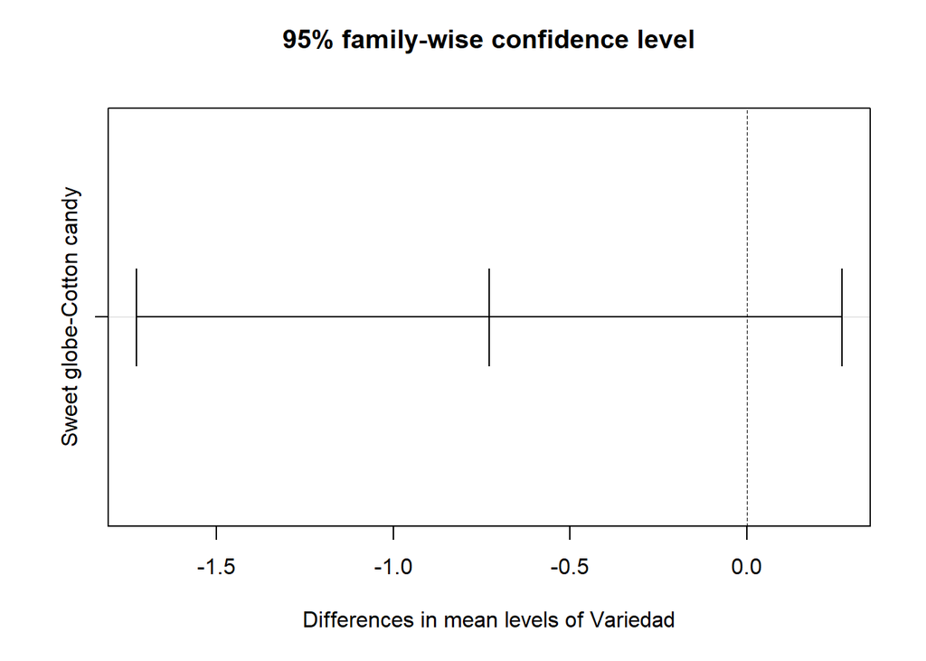

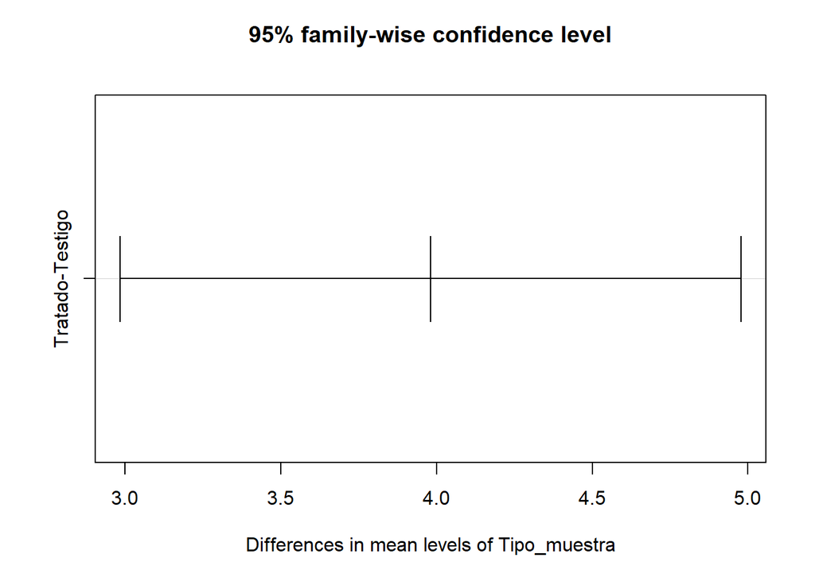

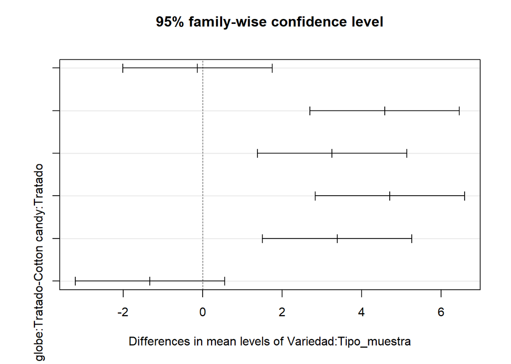

```r
# Prueba Tukey

Anova_tukey <- TukeyHSD(Anova_enz)
plot(Anova_tukey)
```

```r
summary(Anova_enz)
```

```
##                       Df Sum Sq Mean Sq F value   Pr(>F)
## Variedad               1   4.25    4.25   2.242    0.145
## Tipo_muestra           1 126.77  126.77  66.923 6.63e-09 ***
## Variedad:Tipo_muestra  1   2.85    2.85   1.503    0.230
## Residuals             28  53.04    1.89
## ---
## Signif. codes:  0 '***' 0.001 '**' 0.01 '*' 0.05 '.' 0.1 ' ' 1
```

```r
grupos <- HSD.test(Anova_enz, trt = c("Variedad","Tipo_muestra"),
                  alpha = 0.05)
```

### **Interpretación resultados**

1. En las muestras de los tipos de variedades da un valor p = 0.145 por lo que **no** hay diferencias significativas entre la variedad *Sweet globe* y *Cotton candy*
2. En las muestras de los tipos da un valor de p = 6.63e-09, por lo que aquí **si** hay diferencias significativas en las muestras *testigo* y *tratadas*
3. En la interacción de las muestras de variedad con el tipo ya sea testigo o tratado **no** hay diferencia significativa ya que el valor de p = 0.230

#### También se corrió el análisis donde separa por grupos, se puede observar en la siguiente tabla:

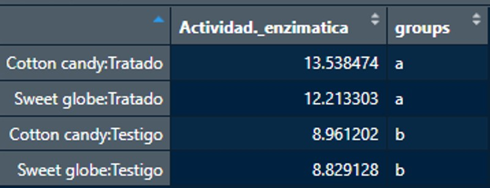

Tabla1

#### El grupo **A** correponde a los tratados en los cuales no hay diferencia significativa, y el grupo **B** corresponde a los testigos, por lo que se concluye lo mismo que se menciona anteriormente que **si** existe una diferencia entre el grupo A y B **Testigos y Tratados**, pero en la variedad no hay diferencia.

#### Las muestras testigo pertenecen a muestras de suelo sin aplicación de producto biológico y las muestras tratadas fueron aplicadas con el producto y si hay un aumento de la actividad enzimatica aplicando el tratamiento por lo cual está relacionado al incremento de microorgnismos en suelo.

#### Para conocer más sobre que es un análisis de varianza tipo ANOVA, a informacion la pueden encontrar en el siguiente link:

[Mas información](https://rpubs.com/Joaquin_AR/219148)

```r
# Cambiar el valor de los resultados de Actividad enzimatica de ug a mg

for (i in 1: nrow(Resultados)) {
  enz_mg <- Resultados$Actividad._enzimatica[i]/1000
  print(enz_mg)
}
```

```
## [1] 0.007550459
## [1] 0.007321101
## [1] 0.008743119
## [1] 0.008513761
## [1] 0.009844037
## [1] 0.009889908
## [1] 0.009385321
## [1] 0.009385321
## [1] 0.008146789
## [1] 0.008330275
## [1] 0.008055046
## [1] 0.008605505
## [1] 0.008055046
## [1] 0.01034862
## [1] 0.009295122
```

[output cut: 17 more lines]

## Ejercicio

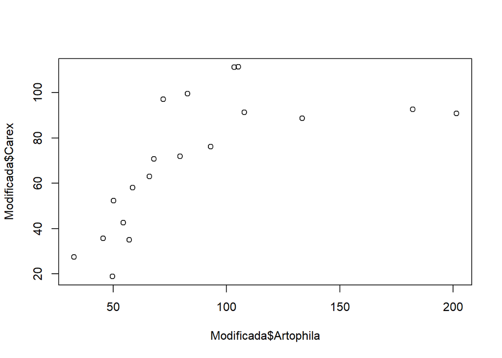

```r
# Seleccionar columnas que vamos a utilizar para el analisis

Tmodificada <- Estanque_de_plantas[,c("Era", "Artophila", "Carex")]

Modificada <- Tmodificada %>%
  filter(!is.na(Artophila),!is.na(Carex)) %>%
  select(Era, Artophila, Carex)


# Verificar si cumple con las funciones

plot(Modificada$Artophila,Modificada$Carex)
```

```r
## Correlacion

cor.test(Modificada$Artophila,Modificada$Carex)
```

```
##
##  Pearson's product-moment correlation
##
## data:  Modificada$Artophila and Modificada$Carex
## t = 3.6467, df = 17, p-value = 0.001996
## alternative hypothesis: true correlation is not equal to 0
## 95 percent confidence interval:
##  0.2979541 0.8584059
## sample estimates:
##       cor
## 0.6625044
```

```r
# Resultados

# El coeficiente de correlación da un valor de 0.6625044 y el p-value =0.001996, por lo que se considera que la correlación es significativa ya que para considerar eso es necesario que el valor de p-value sea <0.05
```